# Risk Factor Analysis

## Outcome Variable

**Outcome Variable:** y_rate_haz

## Predictor Variables

**Intervention Variable:** fhtcm

**Adjustment Set:**

- arm
- W_mage
- W_fage
- meducyrs
- feducyrs
- W_mhtcm
- W_mwtkg
- W_mbmi
- single
- delta_W_fage
- delta_meducyrs
- delta_feducyrs
- delta_W_mhtcm
- delta_W_mwtkg
- delta_W_mbmi
- delta_single

## Stratifying Variables

The analysis was stratified on these variable(s):

- agecat
- studyid
- country

## Data Summary

| agecat | studyid | country | fhtcm | n_cell | n |
| --- | --- | --- | --- | --- | --- |
| 0-3 months | COHORTS | GUATEMALA | >=167 cm | 25 | 180 |
| 0-3 months | COHORTS | GUATEMALA | <162 cm | 106 | 180 |
| 0-3 months | COHORTS | GUATEMALA | [162-167) cm | 49 | 180 |
| 0-3 months | Keneba | GAMBIA | >=167 cm | 631 | 965 |
| 0-3 months | Keneba | GAMBIA | <162 cm | 75 | 965 |
| 0-3 months | Keneba | GAMBIA | [162-167) cm | 259 | 965 |
| 0-3 months | PROBIT | BELARUS | >=167 cm | 10775 | 11502 |
| 0-3 months | PROBIT | BELARUS | <162 cm | 151 | 11502 |
| 0-3 months | PROBIT | BELARUS | [162-167) cm | 576 | 11502 |
| 0-3 months | SAS-CompFeed | INDIA | >=167 cm | 345 | 765 |
| 0-3 months | SAS-CompFeed | INDIA | <162 cm | 196 | 765 |
| 0-3 months | SAS-CompFeed | INDIA | [162-167) cm | 224 | 765 |
| 3-6 months | COHORTS | GUATEMALA | >=167 cm | 37 | 261 |
| 3-6 months | COHORTS | GUATEMALA | <162 cm | 148 | 261 |
| 3-6 months | COHORTS | GUATEMALA | [162-167) cm | 76 | 261 |
| 3-6 months | Keneba | GAMBIA | >=167 cm | 673 | 1037 |
| 3-6 months | Keneba | GAMBIA | <162 cm | 74 | 1037 |
| 3-6 months | Keneba | GAMBIA | [162-167) cm | 290 | 1037 |
| 3-6 months | PROBIT | BELARUS | >=167 cm | 9472 | 10103 |
| 3-6 months | PROBIT | BELARUS | <162 cm | 129 | 10103 |
| 3-6 months | PROBIT | BELARUS | [162-167) cm | 502 | 10103 |
| 3-6 months | SAS-CompFeed | INDIA | >=167 cm | 308 | 682 |
| 3-6 months | SAS-CompFeed | INDIA | <162 cm | 175 | 682 |
| 3-6 months | SAS-CompFeed | INDIA | [162-167) cm | 199 | 682 |
| 6-9 months | COHORTS | GUATEMALA | >=167 cm | 39 | 308 |
| 6-9 months | COHORTS | GUATEMALA | <162 cm | 186 | 308 |
| 6-9 months | COHORTS | GUATEMALA | [162-167) cm | 83 | 308 |
| 6-9 months | Keneba | GAMBIA | >=167 cm | 442 | 663 |
| 6-9 months | Keneba | GAMBIA | <162 cm | 53 | 663 |
| 6-9 months | Keneba | GAMBIA | [162-167) cm | 168 | 663 |

[output cut: 72 more lines]

The following strata were considered:

- agecat: 0-3 months, studyid: COHORTS, country: GUATEMALA
- agecat: 0-3 months, studyid: Keneba, country: GAMBIA
- agecat: 0-3 months, studyid: PROBIT, country: BELARUS
- agecat: 0-3 months, studyid: SAS-CompFeed, country: INDIA
- agecat: 12-15 months, studyid: COHORTS, country: GUATEMALA
- agecat: 12-15 months, studyid: Keneba, country: GAMBIA
- agecat: 12-15 months, studyid: PROBIT, country: BELARUS
- agecat: 12-15 months, studyid: SAS-CompFeed, country: INDIA
- agecat: 12-15 months, studyid: SAS-FoodSuppl, country: INDIA
- agecat: 15-18 months, studyid: COHORTS, country: GUATEMALA
- agecat: 15-18 months, studyid: Keneba, country: GAMBIA
- agecat: 15-18 months, studyid: PROBIT, country: BELARUS
- agecat: 15-18 months, studyid: SAS-CompFeed, country: INDIA
- agecat: 15-18 months, studyid: SAS-FoodSuppl, country: INDIA
- agecat: 18-21 months, studyid: COHORTS, country: GUATEMALA
- agecat: 18-21 months, studyid: Keneba, country: GAMBIA
- agecat: 18-21 months, studyid: PROBIT, country: BELARUS
- agecat: 21-24 months, studyid: COHORTS, country: GUATEMALA
- agecat: 21-24 months, studyid: Keneba, country: GAMBIA
- agecat: 21-24 months, studyid: PROBIT, country: BELARUS
- agecat: 3-6 months, studyid: COHORTS, country: GUATEMALA
- agecat: 3-6 months, studyid: Keneba, country: GAMBIA
- agecat: 3-6 months, studyid: PROBIT, country: BELARUS
- agecat: 3-6 months, studyid: SAS-CompFeed, country: INDIA
- agecat: 6-9 months, studyid: COHORTS, country: GUATEMALA
- agecat: 6-9 months, studyid: Keneba, country: GAMBIA
- agecat: 6-9 months, studyid: PROBIT, country: BELARUS
- agecat: 6-9 months, studyid: SAS-CompFeed, country: INDIA
- agecat: 6-9 months, studyid: SAS-FoodSuppl, country: INDIA
- agecat: 9-12 months, studyid: COHORTS, country: GUATEMALA
- agecat: 9-12 months, studyid: Keneba, country: GAMBIA
- agecat: 9-12 months, studyid: PROBIT, country: BELARUS
- agecat: 9-12 months, studyid: SAS-CompFeed, country: INDIA
- agecat: 9-12 months, studyid: SAS-FoodSuppl, country: INDIA

### Dropped Strata

Some strata were dropped due to rare outcomes:

- agecat: 15-18 months, studyid: PROBIT, country: BELARUS
- agecat: 18-21 months, studyid: PROBIT, country: BELARUS
- agecat: 21-24 months, studyid: PROBIT, country: BELARUS

## Methods Detail

We’re interested in the causal parameters $E[Y_a]$ for all values of $a \in \mathcal{A}$. These parameters represent the mean outcome if, possibly contrary to fact, we intervened to set all units to have $A=a$. Under the randomization and positivity assumptions, these are identified by the statistical parameters $\psi_a=E_W[E_{Y|A,W}(Y|A=a,W)]$. In addition, we’re interested in the mean of $Y$, $E[Y]$ under no intervention (the observed mean). We will estimate these parameters by using SuperLearner to fit the relevant likelihood factors – $E_{Y|A,W}(Y|A=a,W)$ and $p(A=a|W)$, and then updating our likelihood fit using a joint TMLE.

For unadjusted analyses ($W=\{\}$), initial likelihoods were estimated using Lrnr_glm to estimate the simple $E(Y|A)$ and Lrnr_mean to estimate $p(A)$. For adjusted analyses, a small library containing Lrnr_glmnet, Lrnr_xgboost, and Lrnr_mean was used.

# Results Detail

## Results Plots

[figure not shown]

[figure not shown]

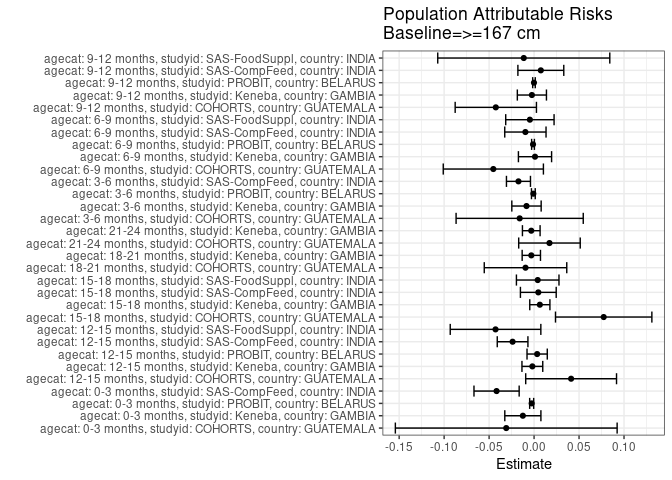

## Results Table

### Parameter: TSM

| agecat | studyid | country | intervention_level | baseline_level | estimate | ci_lower | ci_upper |
| --- | --- | --- | --- | --- | --- | --- | --- |
| 0-3 months | COHORTS | GUATEMALA | >=167 cm | NA | -0.4647342 | -0.5998441 | -0.3296243 |
| 0-3 months | COHORTS | GUATEMALA | <162 cm | NA | -0.4935045 | -0.5511305 | -0.4358786 |
| 0-3 months | COHORTS | GUATEMALA | [162-167) cm | NA | -0.5230372 | -0.6005887 | -0.4454857 |
| 0-3 months | Keneba | GAMBIA | >=167 cm | NA | -0.2800803 | -0.3155597 | -0.2446009 |
| 0-3 months | Keneba | GAMBIA | <162 cm | NA | -0.3213483 | -0.4182687 | -0.2244280 |
| 0-3 months | Keneba | GAMBIA | [162-167) cm | NA | -0.3281148 | -0.3754452 | -0.2807845 |
| 0-3 months | PROBIT | BELARUS | >=167 cm | NA | -0.4313041 | -0.4891094 | -0.3734988 |
| 0-3 months | PROBIT | BELARUS | <162 cm | NA | -0.5053841 | -0.5371893 | -0.4735788 |
| 0-3 months | PROBIT | BELARUS | [162-167) cm | NA | -0.4446895 | -0.5137770 | -0.3756021 |
| 0-3 months | SAS-CompFeed | INDIA | >=167 cm | NA | -0.0876171 | -0.1248424 | -0.0503917 |
| 0-3 months | SAS-CompFeed | INDIA | <162 cm | NA | -0.1628868 | -0.2083145 | -0.1174592 |
| 0-3 months | SAS-CompFeed | INDIA | [162-167) cm | NA | -0.1559179 | -0.2039942 | -0.1078416 |
| 3-6 months | COHORTS | GUATEMALA | >=167 cm | NA | -0.0565652 | -0.1337280 | 0.0205977 |
| 3-6 months | COHORTS | GUATEMALA | <162 cm | NA | -0.1008410 | -0.1339410 | -0.0677411 |
| 3-6 months | COHORTS | GUATEMALA | [162-167) cm | NA | -0.0246519 | -0.0748714 | 0.0255675 |
| 3-6 months | Keneba | GAMBIA | >=167 cm | NA | -0.0158970 | -0.0416139 | 0.0098200 |
| 3-6 months | Keneba | GAMBIA | <162 cm | NA | -0.0538494 | -0.1604354 | 0.0527365 |
| 3-6 months | Keneba | GAMBIA | [162-167) cm | NA | -0.0379885 | -0.0788142 | 0.0028372 |
| 3-6 months | PROBIT | BELARUS | >=167 cm | NA | 0.0504048 | 0.0310697 | 0.0697399 |
| 3-6 months | PROBIT | BELARUS | <162 cm | NA | 0.0437938 | 0.0091167 | 0.0784709 |
| 3-6 months | PROBIT | BELARUS | [162-167) cm | NA | 0.0125658 | -0.0255914 | 0.0507229 |
| 3-6 months | SAS-CompFeed | INDIA | >=167 cm | NA | 0.0001537 | -0.0318225 | 0.0321299 |
| 3-6 months | SAS-CompFeed | INDIA | <162 cm | NA | -0.0341464 | -0.0618738 | -0.0064190 |
| 3-6 months | SAS-CompFeed | INDIA | [162-167) cm | NA | -0.0282016 | -0.0702602 | 0.0138570 |
| 6-9 months | COHORTS | GUATEMALA | >=167 cm | NA | -0.0797199 | -0.1393996 | -0.0200401 |
| 6-9 months | COHORTS | GUATEMALA | <162 cm | NA | -0.1302578 | -0.1560979 | -0.1044177 |
| 6-9 months | COHORTS | GUATEMALA | [162-167) cm | NA | -0.1291425 | -0.1647035 | -0.0935814 |
| 6-9 months | Keneba | GAMBIA | >=167 cm | NA | -0.0172900 | -0.0499722 | 0.0153922 |
| 6-9 months | Keneba | GAMBIA | <162 cm | NA | 0.0531652 | -0.0618696 | 0.1682000 |
| 6-9 months | Keneba | GAMBIA | [162-167) cm | NA | -0.0468053 | -0.0901883 | -0.0034223 |

[output cut: 63 more lines]

### Parameter: E(Y)

| agecat | studyid | country | intervention_level | baseline_level | estimate | ci_lower | ci_upper |
| --- | --- | --- | --- | --- | --- | --- | --- |
| 0-3 months | COHORTS | GUATEMALA | NA | NA | -0.4956734 | -0.5391037 | -0.4522430 |
| 0-3 months | Keneba | GAMBIA | NA | NA | -0.2925541 | -0.3202623 | -0.2648459 |
| 0-3 months | PROBIT | BELARUS | NA | NA | -0.4339788 | -0.4920905 | -0.3758672 |
| 0-3 months | SAS-CompFeed | INDIA | NA | NA | -0.1293116 | -0.1570838 | -0.1015393 |
| 3-6 months | COHORTS | GUATEMALA | NA | NA | -0.0725836 | -0.0990295 | -0.0461377 |
| 3-6 months | Keneba | GAMBIA | NA | NA | -0.0243287 | -0.0453184 | -0.0033389 |
| 3-6 months | PROBIT | BELARUS | NA | NA | 0.0496085 | 0.0303789 | 0.0688381 |
| 3-6 months | SAS-CompFeed | INDIA | NA | NA | -0.0172047 | -0.0462110 | 0.0118016 |
| 6-9 months | COHORTS | GUATEMALA | NA | NA | -0.1250180 | -0.1444785 | -0.1055575 |
| 6-9 months | Keneba | GAMBIA | NA | NA | -0.0162599 | -0.0424084 | 0.0098886 |
| 6-9 months | PROBIT | BELARUS | NA | NA | 0.0501252 | 0.0364772 | 0.0637733 |
| 6-9 months | SAS-CompFeed | INDIA | NA | NA | -0.0826792 | -0.0976756 | -0.0676829 |
| 6-9 months | SAS-FoodSuppl | INDIA | NA | NA | -0.1060840 | -0.1243061 | -0.0878619 |
| 9-12 months | COHORTS | GUATEMALA | NA | NA | -0.0937525 | -0.1108820 | -0.0766229 |
| 9-12 months | Keneba | GAMBIA | NA | NA | -0.1043948 | -0.1248389 | -0.0839507 |
| 9-12 months | PROBIT | BELARUS | NA | NA | 0.0380200 | 0.0165057 | 0.0595343 |
| 9-12 months | SAS-CompFeed | INDIA | NA | NA | -0.0844546 | -0.1064588 | -0.0624505 |
| 9-12 months | SAS-FoodSuppl | INDIA | NA | NA | -0.1543023 | -0.2067725 | -0.1018321 |
| 12-15 months | COHORTS | GUATEMALA | NA | NA | -0.0795786 | -0.0954422 | -0.0637150 |
| 12-15 months | Keneba | GAMBIA | NA | NA | -0.0546831 | -0.0687903 | -0.0405758 |
| 12-15 months | PROBIT | BELARUS | NA | NA | 0.0049023 | -0.1173760 | 0.1271806 |
| 12-15 months | SAS-CompFeed | INDIA | NA | NA | -0.0852063 | -0.1134490 | -0.0569636 |
| 12-15 months | SAS-FoodSuppl | INDIA | NA | NA | 0.0086211 | -0.0272082 | 0.0444504 |
| 15-18 months | COHORTS | GUATEMALA | NA | NA | -0.0589223 | -0.0748896 | -0.0429550 |
| 15-18 months | Keneba | GAMBIA | NA | NA | -0.0340694 | -0.0467538 | -0.0213851 |
| 15-18 months | SAS-CompFeed | INDIA | NA | NA | -0.0056259 | -0.0184980 | 0.0072462 |
| 15-18 months | SAS-FoodSuppl | INDIA | NA | NA | -0.0372612 | -0.0503965 | -0.0241260 |
| 18-21 months | COHORTS | GUATEMALA | NA | NA | -0.0212869 | -0.0355114 | -0.0070623 |
| 18-21 months | Keneba | GAMBIA | NA | NA | -0.0200780 | -0.0325402 | -0.0076159 |
| 21-24 months | COHORTS | GUATEMALA | NA | NA | -0.0126815 | -0.0238129 | -0.0015501 |
| 21-24 months | Keneba | GAMBIA | NA | NA | 0.0182744 | 0.0054117 | 0.0311371 |

### Parameter: ATE

| agecat | studyid | country | intervention_level | baseline_level | estimate | ci_lower | ci_upper |
| --- | --- | --- | --- | --- | --- | --- | --- |
| 0-3 months | COHORTS | GUATEMALA | >=167 cm | >=167 cm | 0.0000000 | 0.0000000 | 0.0000000 |
| 0-3 months | COHORTS | GUATEMALA | <162 cm | >=167 cm | -0.0287703 | -0.1762675 | 0.1187268 |
| 0-3 months | COHORTS | GUATEMALA | [162-167) cm | >=167 cm | -0.0583030 | -0.2145978 | 0.0979918 |
| 0-3 months | Keneba | GAMBIA | >=167 cm | >=167 cm | 0.0000000 | 0.0000000 | 0.0000000 |
| 0-3 months | Keneba | GAMBIA | <162 cm | >=167 cm | -0.0412680 | -0.1444321 | 0.0618961 |
| 0-3 months | Keneba | GAMBIA | [162-167) cm | >=167 cm | -0.0480345 | -0.1072108 | 0.0111417 |
| 0-3 months | PROBIT | BELARUS | >=167 cm | >=167 cm | 0.0000000 | 0.0000000 | 0.0000000 |
| 0-3 months | PROBIT | BELARUS | <162 cm | >=167 cm | -0.0740800 | -0.1230876 | -0.0250724 |
| 0-3 months | PROBIT | BELARUS | [162-167) cm | >=167 cm | -0.0133855 | -0.0463985 | 0.0196275 |
| 0-3 months | SAS-CompFeed | INDIA | >=167 cm | >=167 cm | 0.0000000 | 0.0000000 | 0.0000000 |
| 0-3 months | SAS-CompFeed | INDIA | <162 cm | >=167 cm | -0.0752698 | -0.1377714 | -0.0127682 |
| 0-3 months | SAS-CompFeed | INDIA | [162-167) cm | >=167 cm | -0.0683009 | -0.1176487 | -0.0189530 |
| 3-6 months | COHORTS | GUATEMALA | >=167 cm | >=167 cm | 0.0000000 | 0.0000000 | 0.0000000 |
| 3-6 months | COHORTS | GUATEMALA | <162 cm | >=167 cm | -0.0442759 | -0.1280542 | 0.0395024 |
| 3-6 months | COHORTS | GUATEMALA | [162-167) cm | >=167 cm | 0.0319132 | -0.0601327 | 0.1239591 |
| 3-6 months | Keneba | GAMBIA | >=167 cm | >=167 cm | 0.0000000 | 0.0000000 | 0.0000000 |
| 3-6 months | Keneba | GAMBIA | <162 cm | >=167 cm | -0.0379524 | -0.1476265 | 0.0717217 |
| 3-6 months | Keneba | GAMBIA | [162-167) cm | >=167 cm | -0.0220915 | -0.0705441 | 0.0263610 |
| 3-6 months | PROBIT | BELARUS | >=167 cm | >=167 cm | 0.0000000 | 0.0000000 | 0.0000000 |
| 3-6 months | PROBIT | BELARUS | <162 cm | >=167 cm | -0.0066110 | -0.0412991 | 0.0280771 |
| 3-6 months | PROBIT | BELARUS | [162-167) cm | >=167 cm | -0.0378390 | -0.0770748 | 0.0013968 |
| 3-6 months | SAS-CompFeed | INDIA | >=167 cm | >=167 cm | 0.0000000 | 0.0000000 | 0.0000000 |
| 3-6 months | SAS-CompFeed | INDIA | <162 cm | >=167 cm | -0.0343001 | -0.0622903 | -0.0063098 |
| 3-6 months | SAS-CompFeed | INDIA | [162-167) cm | >=167 cm | -0.0283553 | -0.0584458 | 0.0017352 |
| 6-9 months | COHORTS | GUATEMALA | >=167 cm | >=167 cm | 0.0000000 | 0.0000000 | 0.0000000 |
| 6-9 months | COHORTS | GUATEMALA | <162 cm | >=167 cm | -0.0505380 | -0.1156764 | 0.0146005 |
| 6-9 months | COHORTS | GUATEMALA | [162-167) cm | >=167 cm | -0.0494226 | -0.1188030 | 0.0199578 |
| 6-9 months | Keneba | GAMBIA | >=167 cm | >=167 cm | 0.0000000 | 0.0000000 | 0.0000000 |
| 6-9 months | Keneba | GAMBIA | <162 cm | >=167 cm | 0.0704552 | -0.0490795 | 0.1899898 |
| 6-9 months | Keneba | GAMBIA | [162-167) cm | >=167 cm | -0.0295153 | -0.0840319 | 0.0250012 |

[output cut: 63 more lines]

### Parameter: PAR

| agecat | studyid | country | intervention_level | baseline_level | estimate | ci_lower | ci_upper |
| --- | --- | --- | --- | --- | --- | --- | --- |
| 0-3 months | COHORTS | GUATEMALA | >=167 cm | NA | -0.0309392 | -0.1542216 | 0.0923432 |
| 0-3 months | Keneba | GAMBIA | >=167 cm | NA | -0.0124738 | -0.0325448 | 0.0075972 |
| 0-3 months | PROBIT | BELARUS | >=167 cm | NA | -0.0026748 | -0.0049051 | -0.0004444 |
| 0-3 months | SAS-CompFeed | INDIA | >=167 cm | NA | -0.0416945 | -0.0668117 | -0.0165773 |
| 3-6 months | COHORTS | GUATEMALA | >=167 cm | NA | -0.0160184 | -0.0867078 | 0.0546709 |
| 3-6 months | Keneba | GAMBIA | >=167 cm | NA | -0.0084317 | -0.0247428 | 0.0078794 |
| 3-6 months | PROBIT | BELARUS | >=167 cm | NA | -0.0007963 | -0.0028931 | 0.0013006 |
| 3-6 months | SAS-CompFeed | INDIA | >=167 cm | NA | -0.0173584 | -0.0307074 | -0.0040094 |
| 6-9 months | COHORTS | GUATEMALA | >=167 cm | NA | -0.0452981 | -0.1009748 | 0.0103786 |
| 6-9 months | Keneba | GAMBIA | >=167 cm | NA | 0.0010300 | -0.0174118 | 0.0194718 |
| 6-9 months | PROBIT | BELARUS | >=167 cm | NA | -0.0011739 | -0.0027179 | 0.0003700 |
| 6-9 months | SAS-CompFeed | INDIA | >=167 cm | NA | -0.0096579 | -0.0326132 | 0.0132974 |
| 6-9 months | SAS-FoodSuppl | INDIA | >=167 cm | NA | -0.0046537 | -0.0315322 | 0.0222247 |
| 9-12 months | COHORTS | GUATEMALA | >=167 cm | NA | -0.0425483 | -0.0877268 | 0.0026303 |
| 9-12 months | Keneba | GAMBIA | >=167 cm | NA | -0.0024295 | -0.0186152 | 0.0137562 |
| 9-12 months | PROBIT | BELARUS | >=167 cm | NA | -0.0001134 | -0.0015566 | 0.0013298 |
| 9-12 months | SAS-CompFeed | INDIA | >=167 cm | NA | 0.0075095 | -0.0179949 | 0.0330139 |
| 9-12 months | SAS-FoodSuppl | INDIA | >=167 cm | NA | -0.0114685 | -0.1071088 | 0.0841719 |
| 12-15 months | COHORTS | GUATEMALA | >=167 cm | NA | 0.0411809 | -0.0093061 | 0.0916679 |
| 12-15 months | Keneba | GAMBIA | >=167 cm | NA | -0.0019183 | -0.0134756 | 0.0096389 |
| 12-15 months | PROBIT | BELARUS | >=167 cm | NA | 0.0034193 | -0.0078446 | 0.0146833 |
| 12-15 months | SAS-CompFeed | INDIA | >=167 cm | NA | -0.0238868 | -0.0409334 | -0.0068401 |
| 12-15 months | SAS-FoodSuppl | INDIA | >=167 cm | NA | -0.0428448 | -0.0932108 | 0.0075211 |
| 15-18 months | COHORTS | GUATEMALA | >=167 cm | NA | 0.0773891 | 0.0238166 | 0.1309616 |
| 15-18 months | Keneba | GAMBIA | >=167 cm | NA | 0.0064098 | -0.0047954 | 0.0176150 |
| 15-18 months | SAS-CompFeed | INDIA | >=167 cm | NA | 0.0047095 | -0.0151819 | 0.0246009 |
| 15-18 months | SAS-FoodSuppl | INDIA | >=167 cm | NA | 0.0040330 | -0.0196252 | 0.0276912 |
| 18-21 months | COHORTS | GUATEMALA | >=167 cm | NA | -0.0095230 | -0.0553834 | 0.0363374 |
| 18-21 months | Keneba | GAMBIA | >=167 cm | NA | -0.0030701 | -0.0132523 | 0.0071121 |
| 21-24 months | COHORTS | GUATEMALA | >=167 cm | NA | 0.0171123 | -0.0170963 | 0.0513208 |
| 21-24 months | Keneba | GAMBIA | >=167 cm | NA | -0.0031262 | -0.0129396 | 0.0066873 |